# Mapping data

Francisco Rowe ([`@fcorowe`](http://twitter.com/fcorowe))

2021-11-12

Before diving into this session, let’s ask ourselves:

- Why to create geovisualisations?

For creating maps, cartography is important. A carefully crafted map can be an effective way of communicating complex information. Design issues include poor placement, size and readability of text and careless selection of colors. Have a look the [style guide](https://www.tandf.co.uk//journals/authors/style/TJOM-suppmaterial-quick-guide.pdf) of the Journal of Maps for details.

> For colour palettes, I recommend: * [viridis](https://cran.r-project.org/web/packages/viridis/) * [color brewer 2.0](https://colorbrewer2.org/#type=sequential&scheme=BuGn&n=3)

Crameri, F., Shephard, G.E. and Heron, P.J., 2020. [The misuse of colour in science communication. Nature communications](https://doi.org/10.1038/s41467-020-19160-7), 11(1), pp.1-10.

# Choropleths

Choropleths are thematic maps. They are easy to create but also to get wrong. We’ll look at a set of the principles you can follow to create effective choropleth maps. Here three more questions to consider:

- What is being plotted?
- What is the target audience?
- What degree of interactivity we want to offer?

MacEachren, A.M. and Kraak, M.J., 1997. Exploratory cartographic visualization: advancing the agenda, Computers & Geosciences, 23(4), 335-343.

# Data

We will use [internal migration data](https://www.ons.gov.uk/peoplepopulationandcommunity/populationandmigration/migrationwithintheuk/datasets/internalmigrationbyoriginanddestinationlocalauthoritiessexandsingleyearofagedetailedestimatesdataset) from the Office for National Statistics (ONS) from the United Kingdom.

The original data are organised in a long format structure and are disaggregated by sex and age. Each row captures the count of people moving from an origin to a destination. The spatial units of analysis are local authorities (LA).

```r
# clean workspace
rm(list=ls())

# load data
df_long <- read_csv("../data/internal_migration/Detailed_Estimates_2020_LA_2021_Dataset_1.csv")
# id for origins and destinations
orig_la_nm <- as.data.frame(unique(df_long$OutLA))
dest_la_nm <- as.data.frame(unique(df_long$InLA))

head(df_long)
```

```
## # A tibble: 6 x 5
##   OutLA     InLA        Age Moves Sex
##   <chr>     <chr>     <dbl> <dbl> <chr>
## 1 E06000001 E06000002     0 1.24  M
## 2 E06000001 E06000002     0 0.662 F
## 3 E06000001 E06000002     1 5.09  M
## 4 E06000001 E06000002     1 2.56  F
## 5 E06000001 E06000002     2 2.64  M
## 6 E06000001 E06000002     2 2.54  F
```

We also read our LA boundaries and analyse the structure of the data. We use open data from the ONS’s Geography portal. We use the [Local Authority Districts Boundaries (May 2021) UK BFE](https://geoportal.statistics.gov.uk/datasets/ons::local-authority-districts-may-2021-uk-bfe/about)

```r
# read shapefile
la_shp <- st_read("../data/Local_Authority_Districts_(May_2021)_UK_BFE_V3/LAD_MAY_2021_UK_BFE_V2.shp")
str(la_shp)
```

```
## Classes 'sf' and 'data.frame':   374 obs. of  10 variables:
##  $ OBJECTID  : int  1 2 3 4 5 6 7 8 9 10 ...
##  $ LAD21CD   : chr  "E06000001" "E06000002" "E06000003" "E06000004" ...
##  $ LAD21NM   : chr  "Hartlepool" "Middlesbrough" "Redcar and Cleveland" "Stockton-on-Tees" ...
##  $ BNG_E     : int  447160 451141 464361 444940 428029 354246 362744 369490 332819 511894 ...
##  $ BNG_N     : int  531474 516887 519597 518183 515648 382146 388456 422806 436635 431650 ...
##  $ LONG      : num  -1.27 -1.21 -1.01 -1.31 -1.57 ...
##  $ LAT       : num  54.7 54.5 54.6 54.6 54.5 ...
##  $ SHAPE_Leng: num  66110 41056 105292 108085 107203 ...
##  $ SHAPE_Area: num  9.84e+07 5.46e+07 2.54e+08 2.10e+08 1.97e+08 ...
##  $ geometry  :sfc_MULTIPOLYGON of length 374; first list element: List of 1
##   ..$ :List of 1
##   .. ..$ : num [1:4055, 1:2] 447214 447229 447234 447243 447246 ...
##   ..- attr(*, "class")= chr [1:3] "XY" "MULTIPOLYGON" "sfg"
##  - attr(*, "sf_column")= chr "geometry"
##  - attr(*, "agr")= Factor w/ 3 levels "constant","aggregate",..: NA NA NA NA NA NA NA NA NA
##   ..- attr(*, "names")= chr [1:9] "OBJECTID" "LAD21CD" "LAD21NM" "BNG_E" ...
```

## Computing mobility indicators

Before moving forward we need to define our objective, what is it that we want to visualise / analyse / monitor? *Recall* the principles of research design and planning.

Once we have decided our objective, we can define our metrics.

```r
# out-migration
outflows <- df_long %>%
  group_by(OutLA) %>%
   dplyr::summarise( n = sum(Moves, na.rm = T))

# in-migration
inflows <- df_long %>%
  group_by(InLA) %>%
   dplyr::summarise( n = sum(Moves, na.rm = T))

# net migration
indicators <- full_join(outflows,
                        inflows,
                        by = c("OutLA" = "InLA")) %>%
  mutate_if(is.numeric, ~replace(., is.na(.), 0)) %>%
  mutate_if(is.numeric, round) %>%
  rename(
    outflows = n.x,
    inflows = n.y
  ) %>%
    mutate(
  netflows = (inflows - outflows)
  )
```

## Joining spatial data

```r
la_shp <- left_join(la_shp, indicators, by = c("LAD21CD" = "OutLA"))
```

# Mapping categorical data

Let’s start by mapping categorical data and learning about the UK.

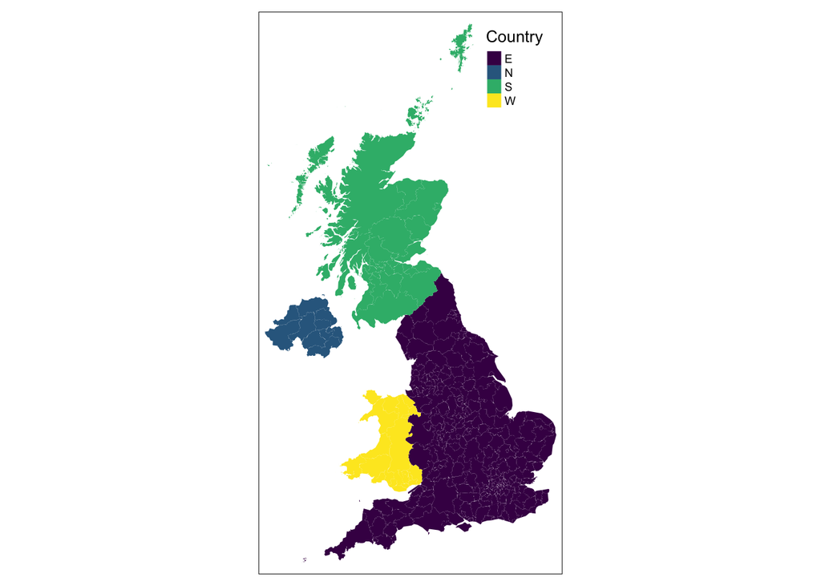

```r
# id for country name initial
la_shp$ctry_nm <- substr(la_shp$LAD21CD, 1, 1)
la_shp$ctry_nm <- as.factor(la_shp$ctry_nm)

# simplify boundaries
la_shp_simple <- st_simplify(la_shp,
                             preserveTopology =T,
                             dTolerance = 1000) # 1km

# ensure geometry is valid
la_shp_simple <- sf::st_make_valid(la_shp_simple)

tm_shape(la_shp_simple) +
  tm_fill(col = "ctry_nm", style = "cat", palette = viridis(4), title = "Country") +
   tm_borders(lwd = 0)  +
    tm_layout(legend.title.size = 1,
          legend.text.size = 0.6,
          legend.position = c("right","top"),
          legend.bg.color = "white",
          legend.bg.alpha = 1)
```

# Mapping continous data

If instead we want to visualise the geographical distribution of a continous phenomenon, we have a few more alternatives.

## Equal interval

An option is ‘equal intervals’. The intuition is to divide the distribution into equal size segments.

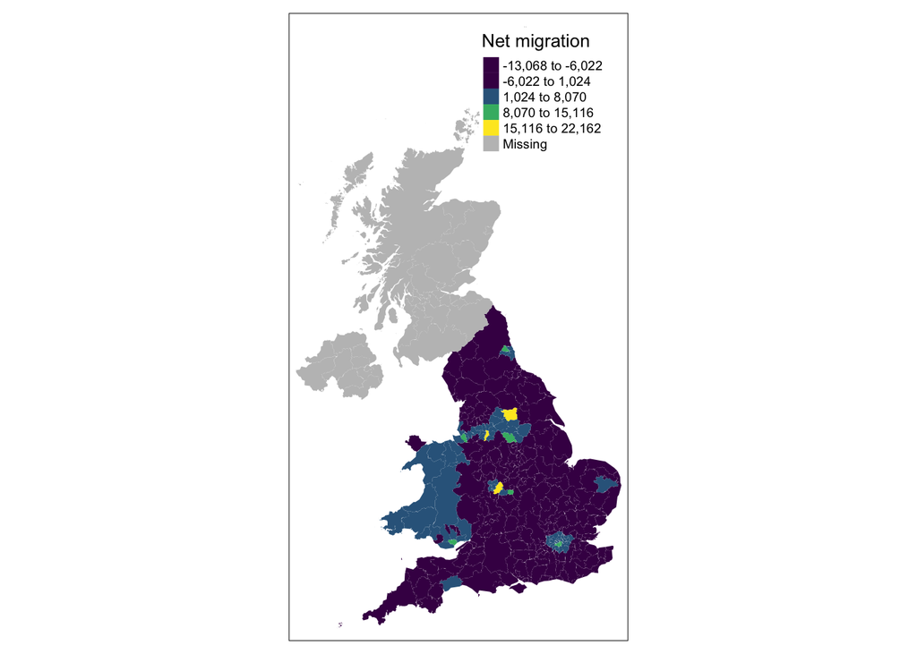

```r
tm_shape(la_shp_simple) +
  tm_fill(col = "netflows", style = "equal", palette = viridis(6), title = "Net migration") +
   tm_borders(lwd = 0) +
  tm_layout(legend.title.size = 1,
          legend.text.size = 0.6,
          legend.position = c("right","top"),
          legend.bg.color = "white",
          legend.bg.alpha = 1)
```

Equal interval bins are more appropriate for variables with a uniform distribution. They are not recommended for variables with a skewed distribution. *Why?*

## Quantiles

This algorithm ensures that the same number of data points fall into each category. A potential issue could be that bin ranges can vary widely.

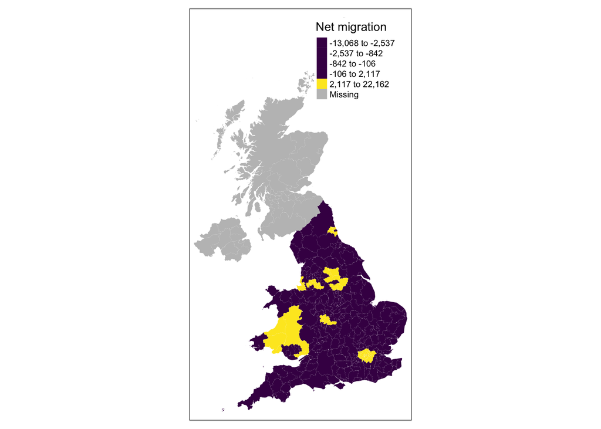

```r
tm_shape(la_shp_simple) +
  tm_fill(col = "netflows", style = "quantile", palette = viridis(6), title = "Net migration") +
   tm_borders(lwd = 0) +
  tm_layout(legend.title.size = 1,
          legend.text.size = 0.6,
          legend.position = c("right","top"),
          legend.bg.color = "white",
          legend.bg.alpha = 1)
```

## Fisher-Jenks

The Fisher-Jenks algorithm, known as ‘natural breaks’, identifies groups of similar values in the data and maximises the differences between categories i.e. *‘natural breaks’*.

Jenks, G.F., 1967. The data model concept in statistical mapping. International yearbook of cartography, 7, pp.186-190. Vancouver

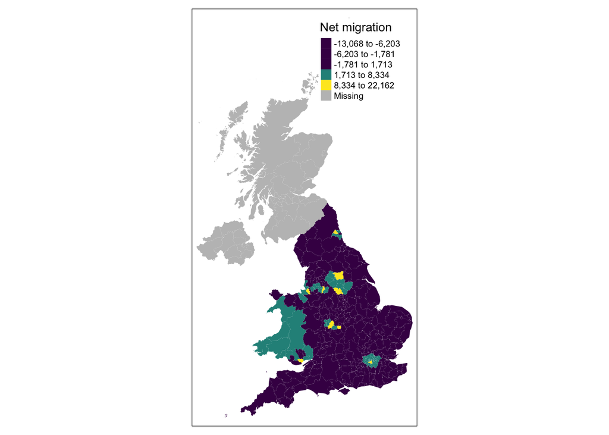

```r
tm_shape(la_shp_simple) +
  tm_fill(col = "netflows", style = "jenks", palette = viridis(6), title = "Net migration") +
   tm_borders(lwd = 0) +
  tm_layout(legend.title.size = 1,
          legend.text.size = 0.6,
          legend.position = c("right","top"),
          legend.bg.color = "white",
          legend.bg.alpha = 1)
```

## Order

Order helps presenting a large number of colors over continuous surface of colours and can be very useful for rasters. `order` can help display skewed distributions.

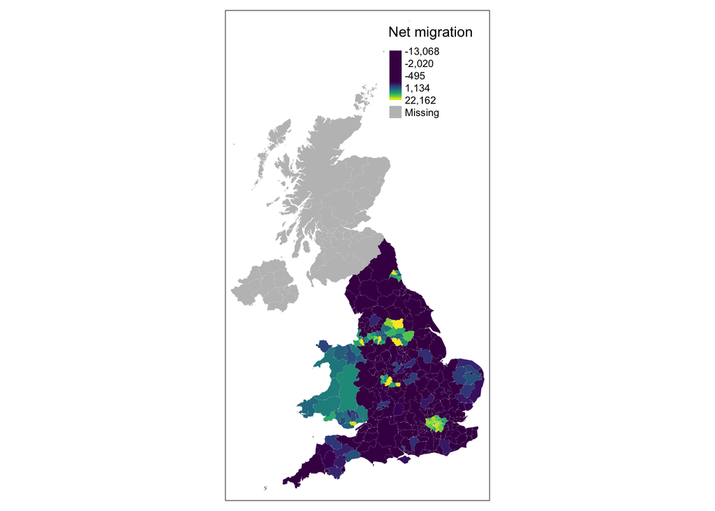

```r
tm_shape(la_shp_simple) +
  tm_fill(col = "netflows", style = "order", palette = viridis(256), title = "Net migration") +
  tm_borders(lwd = 0) +
  tm_layout(legend.title.size = 1,
          legend.text.size = 0.6,
          legend.position = c("right","top"),
          legend.bg.color = "white",
          legend.bg.alpha = 1)
```